# Project Python Foundations: FoodHub Data Analysis

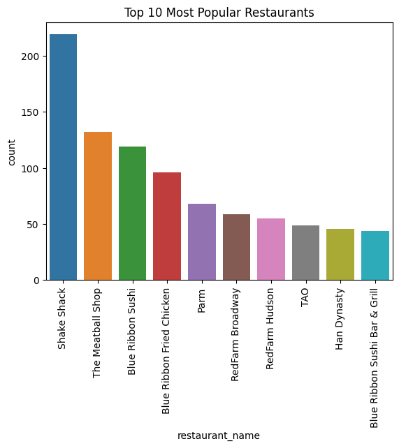

```python
# Restaurants
sns.countplot(data=df, x='restaurant_name', order=df['restaurant_name'].value_counts().index[:10])
plt.xticks(rotation=90)
plt.title('Top 10 Most Popular Restaurants')
```

### Observations: Top 10 restaurants are -

1. Shake Shack
2. The Meatball Shop
3. Blue Ribbon Sushi
4. Blue Ribbon Fried Chicken
5. Parm
6. RedFarm Broadway
7. RedFram Hudson
8. TAO
9. Han Dynasty
10. Blue Ribbon Sushi Bar & Grill

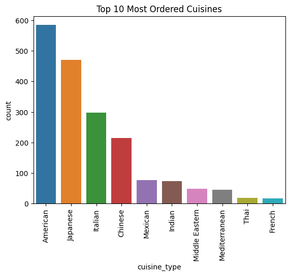

```python
# Cuisines
sns.countplot(data=df, x='cuisine_type', order=df['cuisine_type'].value_counts().index[:10])
plt.xticks(rotation=90)
plt.title('Top 10 Most Ordered Cuisines')
```

### Observations: The top cuisine type are -

1. American
2. Japanese
3. Italian
4. Chinese
5. Mexican
6. Indian
7. Middle Eastern
8. Mediterranean
9. Thai
10. Freanch

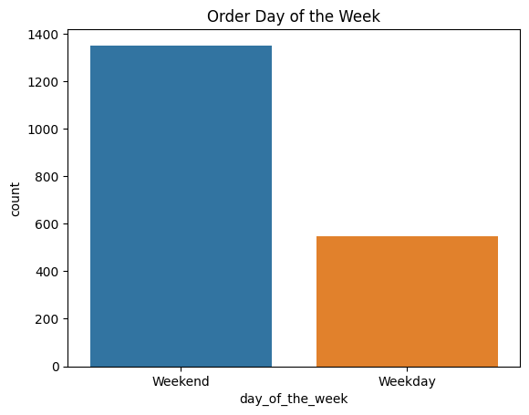

```python
# Order day of week
sns.countplot(data=df, x='day_of_the_week', order=['Weekend', 'Weekday'])
plt.title('Order Day of the Week')
```

```python
df['day_of_the_week'].value_counts()
```

```
Weekend    1351
Weekday     547
Name: day_of_the_week, dtype: int64
```

```python
def percent(ax, feature):
    total = len(feature)
    for p in ax.patches:
        percentage = '{:.1f}%'.format(100 * p.get_height()/total)
        x = p.get_x() + p.get_width() / 2 - 0.05
        y = p.get_y() + p.get_height()
        ax.annotate(percentage, (x, y), size = 12)
```

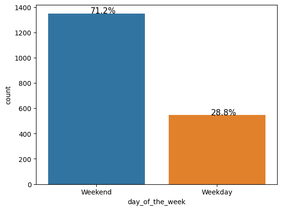

```python
# Distribution of day_of_the_week'
ax = sns.countplot(x=df["day_of_the_week"])

percent(ax, df["day_of_the_week"])
```

### Observations: The number of orders placed on weekends are more than orders placed on weekdays. Out of all the orders on weekdays comprises of about **28.8%** and weekends comprises of about **71.18%**

### **Question 6**: Which are the top 5 restaurants in terms of the number of orders received? [1 mark]

```python
# Write the code here
# Group the data by restaurant_name and count the number of orders for each restaurant
restaurant_order_counts = df['restaurant_name'].value_counts()

# Get the top 5 restaurants with the highest order counts
top_5_restaurants = restaurant_order_counts.head(5)

# Print the top 5 restaurants
print("Top 5 Restaurants by Number of Orders:")
print(top_5_restaurants)
```

```
Top 5 Restaurants by Number of Orders:
Shake Shack                  219
The Meatball Shop            132
Blue Ribbon Sushi            119
Blue Ribbon Fried Chicken     96
Parm                          68
Name: restaurant_name, dtype: int64
```

#### Observations: The top 5 restaurants are -

1. Shake Shack
2. The Meatball Shop
3. Blue Ribbon Sushi
4. Blue Ribbon Fried Chicken
5. Parm